# TDI Capstone Project Proposal:

## Measuring the performance of members of the Australian Parliament

### By Jacques Pienaar

Compared to the US, **voting in Australia is hard**:

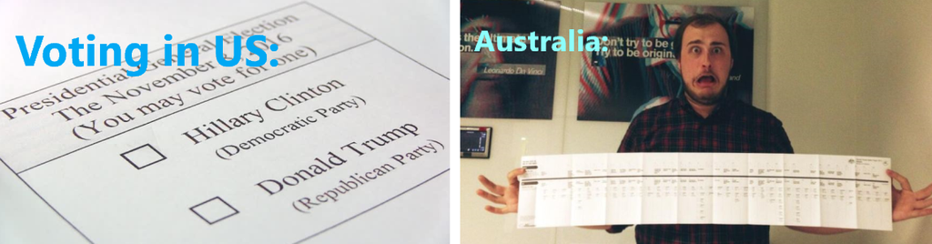

We have the option to list up to **around 100 senators** in order of preference. But most people don't bother because they **don't know anything about individual senators**. Luckily since 2019 the Australian Government has **agreed to make public a large amount of data** about its senators and how they vote in Parliament. My project aims to build a **web application** using this data to display profiles of individual senators, showing how effective they are at their job using a number of **performance metrics**. Here is a wishlist of possible metrics, listed from easy to hard in terms of how accessible the data is:

- How do their voting patterns compare to other senators? **(data via API or download)**
- How high is their attendance to important parliamentary votes? **(data can be scraped)**
- How many bills did they propose, and how many were successful? **(data can be scraped)**
- How much time do they spend with big business lobbyists versus community group lobby? **(data must be inferred)**
- Are their policies influenced by donations from private interests? **(data must be inferred)**

## Example:

I used an API to retrieve data on how all the current senators have voted on all 240 policies, going back to 2006 (about 10MB). Each vote in Parliament is called a **division**. Some policies clearly have a lot more divisions connected to them than others, and are probably more important:

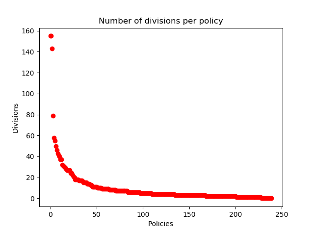

It would be great to see how often each senator attends divisions on important policies, but to get complete attendance data we need to scrape it from the government website.

### Comparing senators on policies

Currently there is a web app that lets you compare how senators vote on a single policy. They use a formula to calculate how much a senator agrees with each policy in terms of the number of "yes", "no", and "absent" votes. Below, numbers of votes that strongly support the policy are labelled "Y,N,A", and votes that weakly support it are labelled "y,n,a". A senator's Agreement score calculated as:

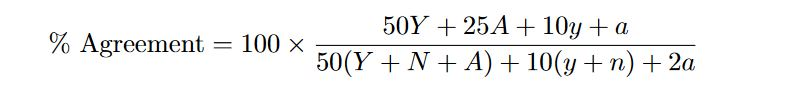

Ideally, we should be able to compare senators across multiple policies, and **group them into clusters** that have similar agreement. Here is an example comparing all senators agreement with just two randomly chosen policies, colour coded by political party:

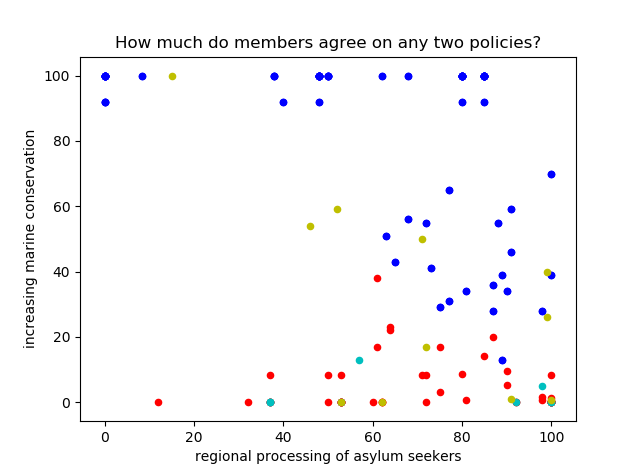

The next step is to compare senators simultaneously across all 240 policies and see if they can be grouped into clusters using a machine learning clustering algorithm. This could tell us surprising things about our senators, like whether they vote similarly to other members of their own party, or are more in agreement with some other party.

### Future dreams

- Use historical data from the same dataset to predict how senators will vote on a policy in the future, and identify senators that might be uncertain about their position on a policy who might be persuaded to change their vote.
- Check for possible corruption: by cross-referencing with another open dataset (490MB), check whether a senator is more likely to vote favourably on policies, or grant government contracts, to private businesses that give more funding to the senator's party.